# Country Clustering

Piotr Wieczorek

2023-05-25

## **Loading the libraries and the data set**

```r
library(factoextra)
library(cluster)
library(readxl)
library(dplyr)
library(kableExtra)
library(gridExtra)
library(forcats)
library(tidyverse)
library(tibble)
```

```r
df <- read_excel("C:/Users/piotr/Desktop/R_files/Dane_scalone (1).xlsx")
```

## **Exploring the data**

### Data set with chosen variables

```r
df <- df %>%
  select(-c(1,7,8,12,15,11,13,14)) %>%
  remove_rownames() %>%
  column_to_rownames(var="Country")
```

```r
df %>%
  select(2,everything()) %>%
  kable(align = "c") %>%
  kable_styling(position="center") %>%
  scroll_box(height='500px',width='100%')
```

|  | region | Total fertility rate | Median age | Life expectancy at birth | Age at first mariage (men) | Age at first mariage (women) | GDP |
| --- | --- | --- | --- | --- | --- | --- | --- |
| Niger | Africa | 6.73 | 14.8 | 60.48 | 24.00 | 17.2 | 590.63 |
| Angola | Africa | 5.76 | 15.9 | 62.51 | 24.70 | 21.4 | 1953.53 |
| DR Congo | Africa | 5.56 | 16.7 | 62.23 | 24.20 | 19.0 | 577.21 |
| Mali | Africa | 5.45 | 16.0 | 62.81 | 25.80 | 18.8 | 873.79 |
| Benin | Africa | 5.39 | 17.0 | 62.60 | 23.80 | 18.7 | 1319.16 |
| Chad | Africa | 5.35 | 16.1 | 59.57 | 24.70 | 18.8 | 685.69 |
| Uganda | Africa | 5.26 | 15.7 | 69.32 | 22.40 | 18.2 | 883.89 |
| Burundi | Africa | 4.96 | 17.7 | 67.77 | 23.60 | 20.3 | 221.48 |
| Guinea | Africa | 4.82 | 19.1 | 64.27 | 28.00 | 19.8 | 1189.18 |
| Mozambique | Africa | 4.74 | 17.0 | 57.70 | 23.40 | 18.7 | 491.84 |
| Liberia | Africa | 4.73 | 18.0 | 65.80 | 23.40 | 18.9 | 675.66 |
| Guinea-Bissau | Africa | 4.65 | 18.0 | 64.10 | 28.10 | 20.9 | 795.12 |
| Nigeria | Africa | 4.57 | 18.6 | 61.79 | 28.60 | 21.2 | 2065.75 |
| Sudan | Africa | 4.54 | 18.3 | 67.45 | 28.90 | 22.0 | 751.82 |
| Afghanistan | South Asia | 4.53 | 19.5 | 54.05 | 24.70 | 15.5 | 368.75 |
| Cameroon | Africa | 4.50 | 18.5 | 63.74 | 25.80 | 19.0 | 1666.93 |
| Zambia | Africa | 4.49 | 16.9 | 66.60 | 23.70 | 18.7 | 1137.34 |
| Tanzania | Africa | 4.33 | 18.2 | 70.48 | 23.80 | 18.9 | 1099.29 |
| Congo | Africa | 4.32 | 19.5 | 62.51 | 25.10 | 21.0 | 2290.38 |
| Togo | Africa | 4.18 | 20.0 | 71.71 | 27.60 | 22.3 | 973.21 |
| Senegal | Africa | 4.17 | 19.4 | 70.25 | 30.60 | 22.2 | 1636.89 |
| Burkina Faso | Africa | 4.14 | 17.9 | 63.82 | 24.30 | 17.9 | 893.08 |
| Central African Republic | Africa | 3.99 | 20.0 | 55.96 | 21.70 | 17.3 | 461.14 |
| Ethiopia | Africa | 3.92 | 19.8 | 68.59 | 25.80 | 21.3 | 925.08 |
| Zimbabwe | Africa | 3.88 | 20.5 | 63.79 | 24.60 | 19.9 | 1773.92 |
| Papua New Guinea | East and Southeast Asia | 3.85 | 24.0 | 69.74 | 25.00 | 21.4 | 2672.95 |
| Sierra Leone | Africa | 3.71 | 19.1 | 59.07 | 27.90 | 23.1 | 480.04 |
| Gambia | Africa | 3.66 | 21.8 | 67.98 | 29.70 | 21.5 | 772.15 |
| Ghana | Africa | 3.61 | 21.4 | 69.72 | 25.70 | 21.7 | 2363.30 |
| Madagascar | Africa | 3.55 | 20.3 | 68.47 | 22.30 | 18.4 | 500.51 |

[output cut: 112 more lines]

### Region frequency

```r
sort(table(df$region),decreasing = TRUE)
```

```
##
##                            Africa                            Europe
##                                45                                37
##           East and Southeast Asia                       Middle East
##                                13                                11
##                     South America             Australia and Oceania
##                                10                                 7
##                        South Asia Central America and the Caribbean
##                                 7                                 6
##                      Central Asia                     North America
##                                 3                                 3
```

### Boxplots characterizing the overall data

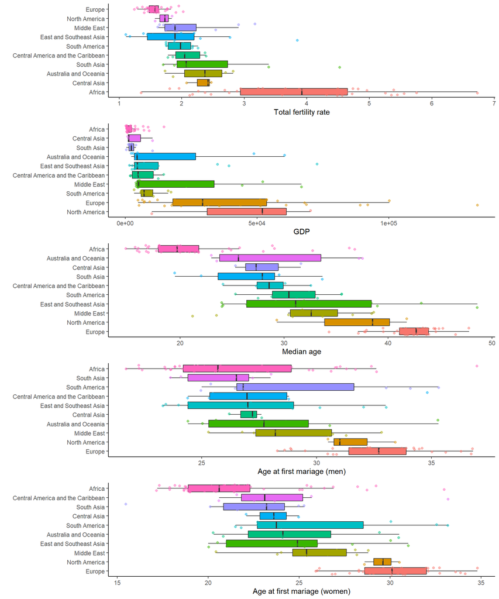

```r
grid.arrange(
  df %>%
  mutate(region = as.factor(region)) %>%
  mutate(region = fct_reorder(region,-`Total fertility rate`)) %>%
  ggplot(aes(y=region,x = `Total fertility rate`,fill=region)) +
  geom_boxplot(outlier.shape = NA)+
  geom_jitter(aes(color=region),alpha=0.5)+
  ylab("")+
  theme_classic()+
  theme(legend.position = "none"),

  df %>%
    mutate(region = as.factor(region)) %>%
    mutate(region = fct_reorder(region,-GDP)) %>%
    ggplot(aes(y=region, x = GDP,fill=region)) +
    geom_boxplot(outlier.shape = NA)+
    geom_jitter(aes(color=region),alpha=0.5)+
    ylab("")+
    theme_classic()+
    theme(legend.position = "none"),

  df %>%
    mutate(region = as.factor(region)) %>%
    mutate(region = fct_reorder(region,-`Median age`)) %>%
    ggplot(aes(y=region, x = `Median age`,fill=region)) +
    geom_boxplot(outlier.shape = NA)+
    geom_jitter(aes(color=region),alpha=0.5)+
    ylab("")+
    theme_classic()+
    theme(legend.position = "none"),

  df %>%
    mutate(region = as.factor(region)) %>%
    mutate(region = fct_reorder(region,-`Age at first mariage (men)`)) %>%
    ggplot(aes(y=region, x = `Age at first mariage (men)`,fill=region)) +
    geom_boxplot(outlier.shape = NA)+
    geom_jitter(aes(color=region),alpha=0.5) +
    ylab("")+
    theme_classic()+
    theme(legend.position = "none"),

  df %>%
    mutate(region = as.factor(region)) %>%
    mutate(region = fct_reorder(region,-`Age at first mariage (women)`)) %>%
    ggplot(aes(y=region, x = `Age at first mariage (women)`,fill=region)) +
    geom_boxplot(outlier.shape = NA)+
    geom_jitter(aes(color=region),alpha=0.5)+
    ylab("")+
    theme_classic()+
    theme(legend.position = "none"),

  ncol=1,nrow=5)
```

### There seems to be a high correlation between GDP and other variables. One could conclude, that wealthy societies are characterized by:

#### High age at first marriage for both men and women

#### High life expectancy at birth

#### High median age

#### Low total fertility rate

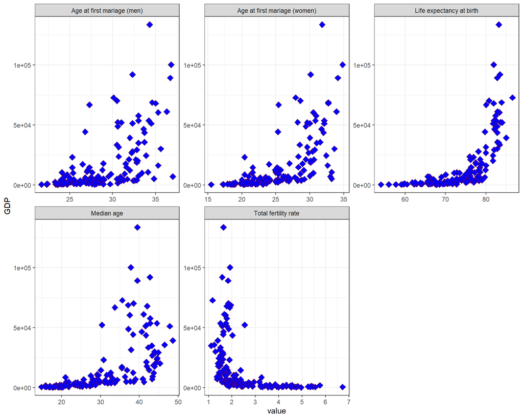

```r
df %>%
  gather(c(`Total fertility rate`, `Median age`, `Life expectancy at birth`,
           `Age at first mariage (men)`,`Age at first mariage (women)`),
         key = "var", value = "value") %>%
  ggplot(aes(x=value,y=GDP)) +
  geom_point(shape=23, fill="blue", color="darkred", size=3) +
  facet_wrap(~ var, scales = "free") +
  theme_bw()
```

### Scaling formula

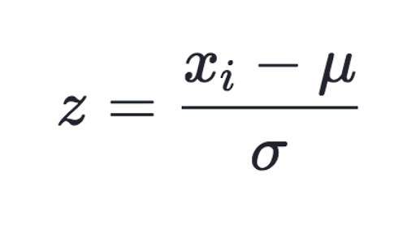

```r
knitr::include_graphics("image/formula1.png")
```

### Selecting and scaling variables

```r
df_scaled <- scale(df[,-c(2)])
```

### Scaled data set

```r
df_scaled %>%
  kable(align = "c") %>%
  kable_styling(position="center") %>%
  scroll_box(width = '100%', height = "500px")
```

|  | Total fertility rate | Median age | Life expectancy at birth | Age at first mariage (men) | Age at first mariage (women) | GDP |
| --- | --- | --- | --- | --- | --- | --- |
| Niger | 3.4710328 | -1.6697676 | -1.9066455 | -1.2562433 | -1.6975987 | -0.6699865 |
| Angola | 2.6704097 | -1.5533882 | -1.6200681 | -1.0721335 | -0.8067515 | -0.6132749 |
| DR Congo | 2.5053328 | -1.4687487 | -1.6595960 | -1.2036405 | -1.3158071 | -0.6705450 |
| Mali | 2.4145405 | -1.5428083 | -1.5777167 | -0.7828183 | -1.3582284 | -0.6582040 |
| Benin | 2.3650174 | -1.4370089 | -1.6073626 | -1.3088460 | -1.3794390 | -0.6396717 |
| Chad | 2.3320020 | -1.5322284 | -2.0351112 | -1.0721335 | -1.3582284 | -0.6660310 |
| Uganda | 2.2577174 | -1.5745481 | -0.6586926 | -1.6770655 | -1.4854922 | -0.6577837 |
| Burundi | 2.0101021 | -1.3629494 | -0.8775079 | -1.3614488 | -1.0400686 | -0.6853472 |
| Guinea | 1.8945482 | -1.2148302 | -1.3716068 | -0.2041877 | -1.1461219 | -0.6450803 |
| Mozambique | 1.8285175 | -1.4370089 | -2.2991012 | -1.4140516 | -1.3794390 | -0.6740973 |
| Liberia | 1.8202636 | -1.3312095 | -1.1556150 | -1.4140516 | -1.3370177 | -0.6664484 |
| Guinea-Bissau | 1.7542328 | -1.3312095 | -1.3956059 | -0.1778863 | -0.9128047 | -0.6614775 |
| Nigeria | 1.6882021 | -1.2677299 | -1.7217113 | -0.0463794 | -0.8491728 | -0.6086053 |
| Sudan | 1.6634405 | -1.2994697 | -0.9226826 | 0.0325248 | -0.6794876 | -0.6632793 |
| Afghanistan | 1.6551867 | -1.1725105 | -2.8143759 | -1.0721335 | -2.0581798 | -0.6792192 |
| Cameroon | 1.6304252 | -1.2783099 | -1.4464276 | -0.7828183 | -1.3158071 | -0.6252006 |
| Zambia | 1.6221713 | -1.4475889 | -1.0426781 | -1.3351474 | -1.3794390 | -0.6472374 |
| Tanzania | 1.4901098 | -1.3100497 | -0.4949341 | -1.3088460 | -1.3370177 | -0.6488207 |
| Congo | 1.4818559 | -1.1725105 | -1.6200681 | -0.9669280 | -0.8915941 | -0.5992582 |
| Togo | 1.3663021 | -1.1196108 | -0.3212936 | -0.3093932 | -0.6158557 | -0.6540670 |
| Senegal | 1.3580483 | -1.1830904 | -0.5274034 | 0.4796484 | -0.6370663 | -0.6264506 |
| Burkina Faso | 1.3332867 | -1.3417895 | -1.4351339 | -1.1773391 | -1.5491242 | -0.6574013 |
| Central African Republic | 1.2094790 | -1.1196108 | -2.5447390 | -1.8611752 | -1.6763881 | -0.6753747 |
| Ethiopia | 1.1517021 | -1.1407707 | -0.7617475 | -0.7828183 | -0.8279621 | -0.6560697 |
| Zimbabwe | 1.1186867 | -1.0667111 | -1.4393690 | -1.0984349 | -1.1249112 | -0.6207486 |
| Papua New Guinea | 1.0939252 | -0.6964133 | -0.5994007 | -0.9932294 | -0.8067515 | -0.5833391 |
| Sierra Leone | 0.9783713 | -1.2148302 | -2.1056968 | -0.2304891 | -0.4461705 | -0.6745883 |
| Gambia | 0.9371021 | -0.9291719 | -0.8478619 | 0.2429359 | -0.7855408 | -0.6624333 |
| Ghana | 0.8958329 | -0.9714916 | -0.6022241 | -0.8091196 | -0.7431196 | -0.5962239 |
| Madagascar | 0.8463098 | -1.0878710 | -0.7786881 | -1.7033669 | -1.4430710 | -0.6737365 |

[output cut: 112 more lines]

## **Choosing the optimal amount of clusters**

### Elblow plot

#### Elblow plot pictures the dependency between the quantity of clusters and total sum of square within each clutser. In clustering it is wanted to obtain low variance within the clusters and high variance betweeen the clusters so that there is a clear distinction between the groups. Based on the plot, 3 clusters seem to be optimal

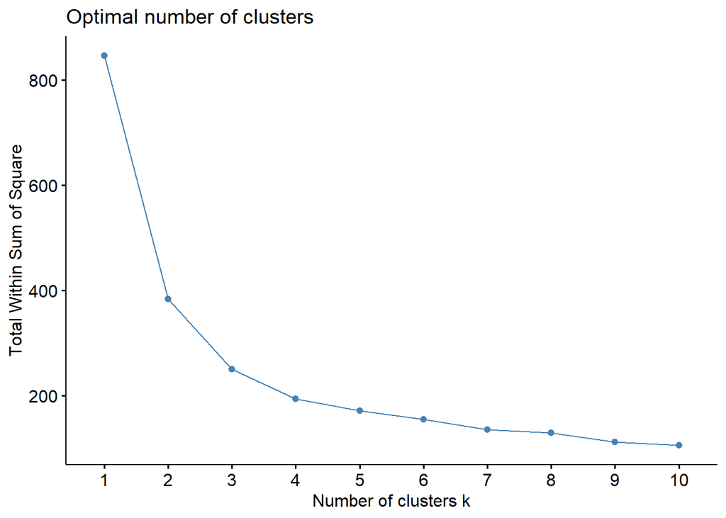

```r
fviz_nbclust(df_scaled,kmeans,method="wss")
```

### Silhouette plot

#### Silhouette plot points 2 clusters as the optimal value. Silhouette score measures the difference between each observation and all other data points of the nearest cluster b(i) and the average distance between each data point within a cluster a(i). The result is then divided by maximum either a(i) or b(i). The higher the score, the better the clusters are separated and the lower the variance within the clusters. Although it suggests 2 clusters, 3 clusters were chosen as 2 clusters don’t seem to fit the charactertic of the data set.

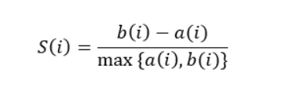

Source = https://www.analyticsvidhya.com/blog/2021/05/k-mean-getting-the-optimal-number-of-clusters/

```r
knitr::include_graphics("image/formula2.png")
```

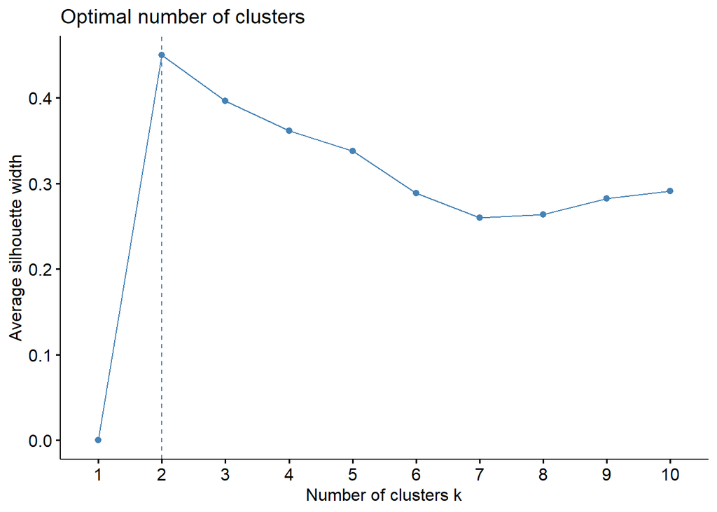

```r
fviz_nbclust(df_scaled,kmeans,method="silhouette")
```

## **K-means algorithm**

```r
df_scaled_fit <- kmeans(df_scaled,3,nstart = 100)
```

### Between_SS and total_SS

#### (between_SS / total_SS) = 70.5 % means that 70.5 % of the total variance in the data set is explained by the clustering

```r
df_scaled_fit
```

```
## K-means clustering with 3 clusters of sizes 55, 38, 49
##
## Cluster means:
##   Total fertility rate Median age Life expectancy at birth
## 1           -0.3634038 -0.0598857               0.05940648
## 2            1.4518814 -1.2259670              -1.24340116
## 3           -0.7180466  1.0179686               0.89758955
##   Age at first mariage (men) Age at first mariage (women)        GDP
## 1                 -0.3154187                   -0.2224945 -0.4456865
## 2                 -0.8997902                   -1.1226785 -0.6380526
## 3                  1.0518378                    1.1203874  0.9950766
##
## Clustering vector:
##                    Niger                   Angola                 DR Congo
##                        2                        2                        2
##                     Mali                    Benin                     Chad
##                        2                        2                        2
##                   Uganda                  Burundi                   Guinea
##                        2                        2                        2
##               Mozambique                  Liberia            Guinea-Bissau
##                        2                        2                        2
##                  Nigeria                    Sudan              Afghanistan
##                        2                        2                        2
##                 Cameroon                   Zambia                 Tanzania
##                        2                        2                        2
##                    Congo                     Togo                  Senegal
##                        2                        2                        2
##             Burkina Faso Central African Republic                 Ethiopia
##                        2                        2                        2
##                 Zimbabwe         Papua New Guinea             Sierra Leone
##                        2                        2                        2
##                   Gambia                    Ghana               Madagascar
##                        2                        2                        2
##               Mauritania                 Pakistan                   Malawi
##                        2                        2                        2
##                    Gabon                   Rwanda                    Kenya
##                        2                        2                        2
##                     Iraq                  Namibia                   Jordan
##                        1                        1                        1
##                  Lesotho          Solomon Islands              Philippines
```

[output cut: 63 more lines]

```
##                    Japan   Bosnia and Herzegovina                Mauritius
##                        3                        1                        1
##                    Spain                    Italy                Singapore
##                        3                        3                        3
##              South Korea
##                        3
##
## Within cluster sum of squares by cluster:
## [1]  77.07386  53.76305 118.53433
##  (between_SS / total_SS =  70.5 %)
##
## Available components:
##
## [1] "cluster"      "centers"      "totss"        "withinss"     "tot.withinss"
## [6] "betweenss"    "size"         "iter"         "ifault"
```

### Cluster centers

```r
df_scaled_fit$centers
```

```
##   Total fertility rate Median age Life expectancy at birth
## 1           -0.3634038 -0.0598857               0.05940648
## 2            1.4518814 -1.2259670              -1.24340116
## 3           -0.7180466  1.0179686               0.89758955
##   Age at first mariage (men) Age at first mariage (women)        GDP
## 1                 -0.3154187                   -0.2224945 -0.4456865
## 2                 -0.8997902                   -1.1226785 -0.6380526
## 3                  1.0518378                    1.1203874  0.9950766
```

### Adding the clusters to the original data set

```r
df$clusters <- df_scaled_fit$cluster
```

```r
df %>%
  kable(align = "c") %>%
  kable_styling(position="center") %>%
  scroll_box(width = '100%', height = "500px")
```

|  | Total fertility rate | region | Median age | Life expectancy at birth | Age at first mariage (men) | Age at first mariage (women) | GDP | clusters |
| --- | --- | --- | --- | --- | --- | --- | --- | --- |
| Niger | 6.73 | Africa | 14.8 | 60.48 | 24.00 | 17.2 | 590.63 | 2 |
| Angola | 5.76 | Africa | 15.9 | 62.51 | 24.70 | 21.4 | 1953.53 | 2 |
| DR Congo | 5.56 | Africa | 16.7 | 62.23 | 24.20 | 19.0 | 577.21 | 2 |
| Mali | 5.45 | Africa | 16.0 | 62.81 | 25.80 | 18.8 | 873.79 | 2 |
| Benin | 5.39 | Africa | 17.0 | 62.60 | 23.80 | 18.7 | 1319.16 | 2 |
| Chad | 5.35 | Africa | 16.1 | 59.57 | 24.70 | 18.8 | 685.69 | 2 |
| Uganda | 5.26 | Africa | 15.7 | 69.32 | 22.40 | 18.2 | 883.89 | 2 |
| Burundi | 4.96 | Africa | 17.7 | 67.77 | 23.60 | 20.3 | 221.48 | 2 |
| Guinea | 4.82 | Africa | 19.1 | 64.27 | 28.00 | 19.8 | 1189.18 | 2 |
| Mozambique | 4.74 | Africa | 17.0 | 57.70 | 23.40 | 18.7 | 491.84 | 2 |
| Liberia | 4.73 | Africa | 18.0 | 65.80 | 23.40 | 18.9 | 675.66 | 2 |
| Guinea-Bissau | 4.65 | Africa | 18.0 | 64.10 | 28.10 | 20.9 | 795.12 | 2 |
| Nigeria | 4.57 | Africa | 18.6 | 61.79 | 28.60 | 21.2 | 2065.75 | 2 |
| Sudan | 4.54 | Africa | 18.3 | 67.45 | 28.90 | 22.0 | 751.82 | 2 |
| Afghanistan | 4.53 | South Asia | 19.5 | 54.05 | 24.70 | 15.5 | 368.75 | 2 |
| Cameroon | 4.50 | Africa | 18.5 | 63.74 | 25.80 | 19.0 | 1666.93 | 2 |
| Zambia | 4.49 | Africa | 16.9 | 66.60 | 23.70 | 18.7 | 1137.34 | 2 |
| Tanzania | 4.33 | Africa | 18.2 | 70.48 | 23.80 | 18.9 | 1099.29 | 2 |
| Congo | 4.32 | Africa | 19.5 | 62.51 | 25.10 | 21.0 | 2290.38 | 2 |
| Togo | 4.18 | Africa | 20.0 | 71.71 | 27.60 | 22.3 | 973.21 | 2 |
| Senegal | 4.17 | Africa | 19.4 | 70.25 | 30.60 | 22.2 | 1636.89 | 2 |
| Burkina Faso | 4.14 | Africa | 17.9 | 63.82 | 24.30 | 17.9 | 893.08 | 2 |
| Central African Republic | 3.99 | Africa | 20.0 | 55.96 | 21.70 | 17.3 | 461.14 | 2 |
| Ethiopia | 3.92 | Africa | 19.8 | 68.59 | 25.80 | 21.3 | 925.08 | 2 |
| Zimbabwe | 3.88 | Africa | 20.5 | 63.79 | 24.60 | 19.9 | 1773.92 | 2 |
| Papua New Guinea | 3.85 | East and Southeast Asia | 24.0 | 69.74 | 25.00 | 21.4 | 2672.95 | 2 |
| Sierra Leone | 3.71 | Africa | 19.1 | 59.07 | 27.90 | 23.1 | 480.04 | 2 |
| Gambia | 3.66 | Africa | 21.8 | 67.98 | 29.70 | 21.5 | 772.15 | 2 |
| Ghana | 3.61 | Africa | 21.4 | 69.72 | 25.70 | 21.7 | 2363.30 | 2 |
| Madagascar | 3.55 | Africa | 20.3 | 68.47 | 22.30 | 18.4 | 500.51 | 2 |

[output cut: 112 more lines]

### Clustering plot

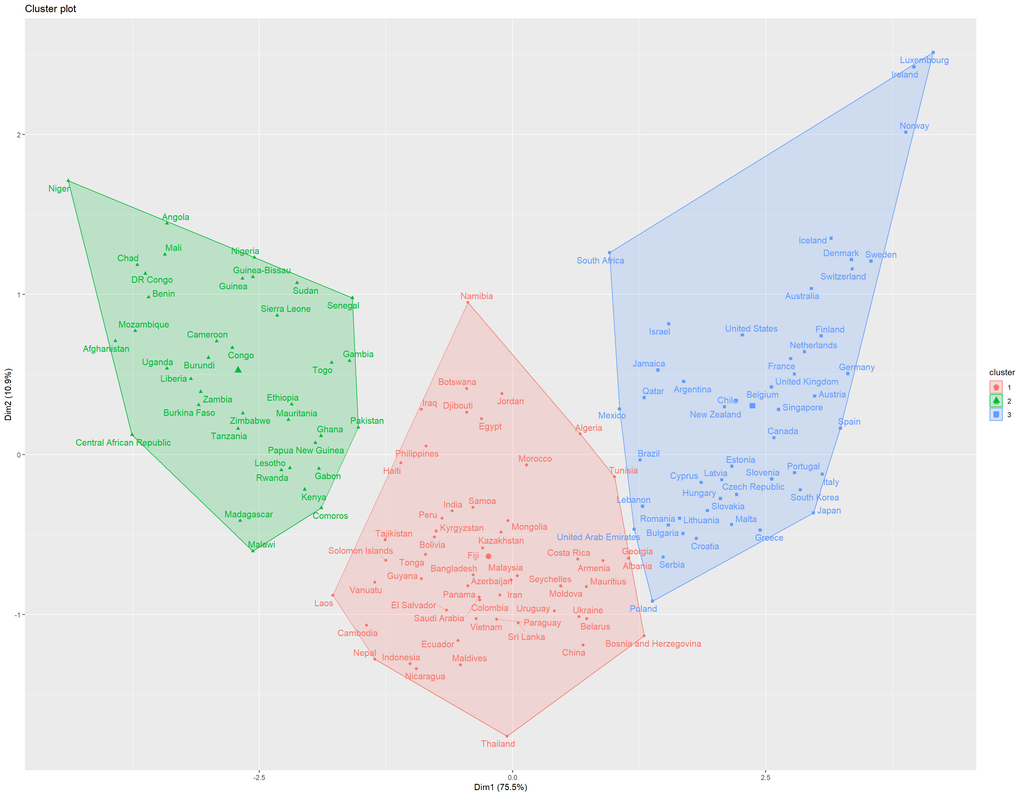

```r
#rownames(df_scaled) <- paste(df$Country,1:dim(df)[1],sep="_")
fviz_cluster(list(data=df_scaled,cluster= df_scaled_fit$cluster),repel = TRUE)
```

## **Fuzzy clustering**

```r
res_fuzzy <- fanny(df_scaled,k=3)
```

```r
membership <- as.data.frame(res_fuzzy$membership)
colnames(membership) <- c("First cluster","Second cluster", "Third cluster")
membership[,1:3] <- sapply(membership, function(x) round(x,2))
```

```r
membership %>%
  kable(align = "c") %>%
  kable_styling(position="center") %>%
  scroll_box(height='500px',width='100%')
```

|  | First cluster | Second cluster | Third cluster |
| --- | --- | --- | --- |
| Niger | 0.54 | 0.27 | 0.19 |
| Angola | 0.60 | 0.24 | 0.15 |
| DR Congo | 0.63 | 0.23 | 0.14 |
| Mali | 0.63 | 0.23 | 0.14 |
| Benin | 0.64 | 0.23 | 0.14 |
| Chad | 0.62 | 0.23 | 0.15 |
| Uganda | 0.60 | 0.25 | 0.15 |
| Burundi | 0.66 | 0.22 | 0.12 |
| Guinea | 0.65 | 0.22 | 0.13 |
| Mozambique | 0.61 | 0.24 | 0.15 |
| Liberia | 0.68 | 0.20 | 0.11 |
| Guinea-Bissau | 0.65 | 0.22 | 0.13 |
| Nigeria | 0.62 | 0.24 | 0.14 |
| Sudan | 0.61 | 0.25 | 0.14 |
| Afghanistan | 0.56 | 0.27 | 0.17 |
| Cameroon | 0.71 | 0.19 | 0.10 |
| Zambia | 0.69 | 0.20 | 0.11 |
| Tanzania | 0.65 | 0.23 | 0.12 |
| Congo | 0.70 | 0.20 | 0.11 |
| Togo | 0.58 | 0.28 | 0.14 |
| Senegal | 0.51 | 0.32 | 0.17 |
| Burkina Faso | 0.69 | 0.20 | 0.11 |
| Central African Republic | 0.56 | 0.27 | 0.17 |
| Ethiopia | 0.69 | 0.21 | 0.10 |
| Zimbabwe | 0.70 | 0.20 | 0.10 |
| Papua New Guinea | 0.63 | 0.26 | 0.11 |
| Sierra Leone | 0.57 | 0.28 | 0.15 |
| Gambia | 0.54 | 0.31 | 0.15 |
| Ghana | 0.64 | 0.26 | 0.11 |
| Madagascar | 0.61 | 0.26 | 0.13 |

[output cut: 112 more lines]

```r
optimal_cluster_df <- as.data.frame(res_fuzzy$clustering)
colnames(optimal_cluster_df) <- c("optimal_cluster")
```

```r
optimal_cluster_df$optimal_cluster
```

```
##   [1] 1 1 1 1 1 1 1 1 1 1 1 1 1 1 1 1 1 1 1 1 1 1 1 1 1 1 1 1 1 1 1 1 1 1 1 1 2
##  [38] 2 2 1 2 2 2 2 1 2 3 2 2 2 2 2 2 2 1 2 2 2 2 2 3 3 2 2 2 2 2 3 2 2 3 2 2 2
##  [75] 3 3 2 2 3 3 2 2 2 2 2 2 3 3 3 2 2 3 3 3 3 2 3 3 2 3 3 3 3 2 3 2 3 3 3 3 3
## [112] 3 3 2 3 3 3 2 3 3 2 2 3 3 3 3 3 3 3 3 3 2 3 3 3 3 3 2 3 3 3 3
```

```r
membership$optimal_cluster <- optimal_cluster_df$optimal_cluster
```

```r
membership %>%
  kable(align = "c") %>%
  kable_styling(position="center") %>%
  scroll_box(height='500px',width='100%')
```

|  | First cluster | Second cluster | Third cluster | optimal_cluster |
| --- | --- | --- | --- | --- |
| Niger | 0.54 | 0.27 | 0.19 | 1 |
| Angola | 0.60 | 0.24 | 0.15 | 1 |
| DR Congo | 0.63 | 0.23 | 0.14 | 1 |
| Mali | 0.63 | 0.23 | 0.14 | 1 |
| Benin | 0.64 | 0.23 | 0.14 | 1 |
| Chad | 0.62 | 0.23 | 0.15 | 1 |
| Uganda | 0.60 | 0.25 | 0.15 | 1 |
| Burundi | 0.66 | 0.22 | 0.12 | 1 |
| Guinea | 0.65 | 0.22 | 0.13 | 1 |
| Mozambique | 0.61 | 0.24 | 0.15 | 1 |
| Liberia | 0.68 | 0.20 | 0.11 | 1 |
| Guinea-Bissau | 0.65 | 0.22 | 0.13 | 1 |
| Nigeria | 0.62 | 0.24 | 0.14 | 1 |
| Sudan | 0.61 | 0.25 | 0.14 | 1 |
| Afghanistan | 0.56 | 0.27 | 0.17 | 1 |
| Cameroon | 0.71 | 0.19 | 0.10 | 1 |
| Zambia | 0.69 | 0.20 | 0.11 | 1 |
| Tanzania | 0.65 | 0.23 | 0.12 | 1 |
| Congo | 0.70 | 0.20 | 0.11 | 1 |
| Togo | 0.58 | 0.28 | 0.14 | 1 |
| Senegal | 0.51 | 0.32 | 0.17 | 1 |
| Burkina Faso | 0.69 | 0.20 | 0.11 | 1 |
| Central African Republic | 0.56 | 0.27 | 0.17 | 1 |
| Ethiopia | 0.69 | 0.21 | 0.10 | 1 |
| Zimbabwe | 0.70 | 0.20 | 0.10 | 1 |
| Papua New Guinea | 0.63 | 0.26 | 0.11 | 1 |
| Sierra Leone | 0.57 | 0.28 | 0.15 | 1 |
| Gambia | 0.54 | 0.31 | 0.15 | 1 |
| Ghana | 0.64 | 0.26 | 0.11 | 1 |
| Madagascar | 0.61 | 0.26 | 0.13 | 1 |

[output cut: 112 more lines]

### Dunn’s coefficient

#### According to the [library’s documentation](https://search.r-project.org/CRAN/refmans/clValid/html/dunn.html), low values of Dunn’s coefficient indicate very fuzzy clustering, while a value close to 1 indicates close to tight clustering. Judging on it’s value (0.4362) conducted clustering seems to be more fuzzy than tight.

```r
res_fuzzy$coeff
```

```
## dunn_coeff normalized
##  0.4361986  0.1542979
```